# Chloé RICHARD

## 5.2 Méthodes à gradient boosting

### 5.2.1 Extreme Gradient Boosting (XGBoost)

XGBoost pour Extreme Gradient Boosting est un algorithme d'apprentissage supervisé qui repose sur le principe de Gradient Boosting Trees. La principale différence réside dans le fait que XGBoost traite les données en plusieurs blocs compressés permettant de les trier beaucoup plus rapidement qu'avec un Gradient Boosting classique, et de les traiter en parallèle. Aussi, XGBoost propose un panel d’hyperparamètres permettant de contrôler l’implémentation du Gradient Boosting et de limiter les risques d'overfitting.

Dans ce but, 4 paramètres m'ont semblé importants :

- `n_estimators` ( et `early_stopping`) : qui correspond au nombre de sous-arbres qui seront formés. Il permet d'anticiper l'arrêt de l'apprentissage lorsque le modèle commencer à mémoriser les données d'entraînement, dégradant de ce fait les performances sur l'ensemble de validation.
- `learning_rate` : vitesse d'apprentissage, chaque poids dans tous les arbres sera multiplié par cette valeur. On observe que plus ce taux d'apprentissage est petit, meilleures sont les performances.
- `max_depth`: correspond à la profondeur maximale de chaque arbre. Plus cette valeur est grande, plus le modèle est complexe.
- `reg_alpha` et `reg_lamnda` : ce sont des paramètres qui contrôlent les termes de régularisation L1 et L2 de la fonction de perte.

```python
# split du jeu d'apprentissage en train - validation
X_train, X_valid, y_train, y_valid = train_test_split(xtrain , ytrain, train_size = 0.95, random_state = 42,stratify = ytrain)
```

```python
# ignorer l'affichage de warnings
warnings.filterwarnings("ignore")

# création du classifieur xgb
xgb = XGBClassifier(eta = 0.05,gamma = 3, max_depth = 4, min_child_weight = 1, colsample_bytree = 0.5,
                    n_jobs =- 1, alpha = 3, scale_pos_weight = 2, random_state = 42);


# entraînement du classifieur xgb
%time xgb.fit(X_train, y_train.values.ravel())

# prédiction des classes
y_pred_valid_xgb = xgb.predict(X_valid)

# prédiction de la probabilité d'anomalie
y_pred_prob_valid_xgb = xgb.predict_proba(X_valid)[:, 1]

# pour soumission
# xtest_pred_xgb = xgb.predict_proba(xtest)[:, 1]
# print(f"Shape de xtest_pred_xgb : {xtest_pred_xgb}")
# np.savetxt('ytest_challenge_student_final_xgb.csv', xtest_pred_xgb, fmt = '%1.6f', delimiter=',')
```

```
[10:17:36] WARNING: /Users/travis/build/dmlc/xgboost/src/learner.cc:1061: Starting in XGBoost 1.3.0, the default evaluation metric used with the objective 'binary:logistic' was changed from 'error' to 'logloss'. Explicitly set eval_metric if you'd like to restore the old behavior.
CPU times: user 3.86 s, sys: 42.3 ms, total: 3.9 s
Wall time: 1.16 s
```

```python
# calcul AUC
print(f"\nAUROC: {roc_auc_score(y_valid, y_pred_prob_valid_xgb)}\n");

# calcul des métriques classification
classification_report = classification_report(y_valid, y_pred_valid_xgb)
confusion_matrix = confusion_matrix(y_valid, y_pred_valid_xgb)
print("CLASSIFICATION REPORT")
print(classification_report)

# calcul matrice de confusion
print("CONFUSION MATRIX")
print(confusion_matrix)
```

```
AUROC: 0.9195751460435475

CLASSIFICATION REPORT
              precision    recall  f1-score   support

           0       0.98      0.99      0.99      1345
           1       0.54      0.37      0.44        35

    accuracy                           0.98      1380
   macro avg       0.76      0.68      0.71      1380
weighted avg       0.97      0.98      0.97      1380

CONFUSION MATRIX
[[1334   11]
 [  22   13]]
```

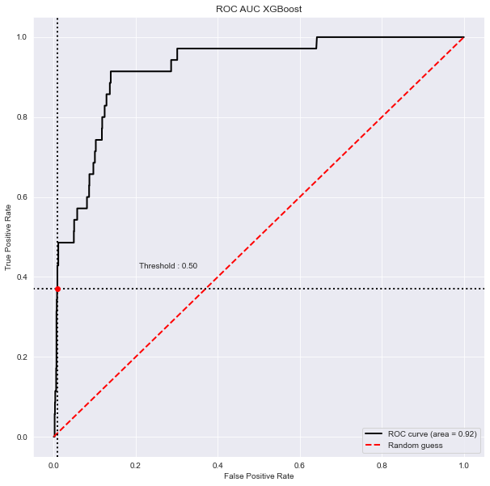

```python
# visualisation courbe ROC xgb
bc = BinaryClassification(y_valid, y_pred_prob_valid_xgb, labels=["Class normale", "Class anormale"])

# Figures
plt.figure(figsize=(10, 10))
bc.plot_roc_curve()
plt.title('ROC AUC XGBoost')
plt.show()
```

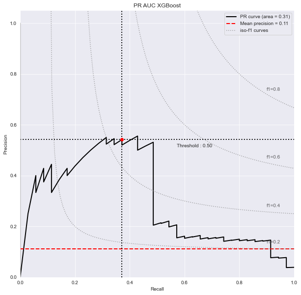

```python
# visualisation de la courbe precision recall
bc = BinaryClassification(y_valid, y_pred_prob_valid_xgb, labels=["Class normale", "Class anormale"])

plt.figure(figsize=(10, 10))
bc.plot_precision_recall_curve()
plt.title('PR AUC XGBoost')
plt.show()
```

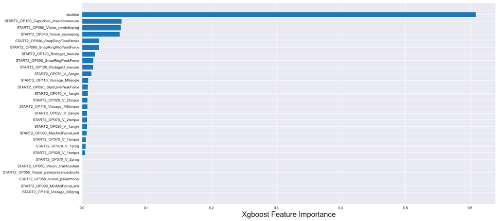

```python
# visualisation feature importance par xgboost
plt.figure(figsize=(20,10))
sorted_idx = xgb.feature_importances_.argsort()
plt.barh(xtrain.columns[sorted_idx], xgb.feature_importances_[sorted_idx])
plt.xlabel("Xgboost Feature Importance", fontsize = 20)
```

> **Interprétation** : on constate que la variable doublon est très importante par rapport aux autres features dans le cadre de cette classification. Elle est la variable qui explique le plus la variable d'intérêt. Sans cette nouvelle feature, la classe anormale n'aurait pas bien été discriminé par les autres variables et les scores auraient été beaucoup moins bon.

Pour conclure, nous obtenons comme prévu de bons résultats concernant les prédictions appartenant à la classe normale. Étant donné que les classes sont fortement déséquilibrées, nous avons une précision globale bonne, pourtant les résultats de prédiction de classe anormale ne sont pas assez satisfaisants.

Toute l'information de la variable anomalie n'est donc pas apportée par les covariables de notre jeu de données. Nous essayerons ainsi d'améliorer notre score en implémentant une version spécifique à la détection d'outliers de XGBoost.

### 5.2.2 Extreme Boosting Based Outlier Detection (XGBOD)

XGBOD a l'avantage de générer de nouvelles représentations de données. Plus précisément, plusieurs méthodes de détection de valeurs aberrantes (outliers) non-supervisées sont appliquées aux données brutes. Un processus de sélection est ensuite effectué sur les scores de ces valeurs aberrantes générés afin de conserver uniquement les scores pertinents. Ces scores sélectionnés sont ensuite combinés avec les caractéristiques originales du jeu de données afin de définir un le nouvel espace de caractéristiques plus représentatif de notre jeu de données initial déséquilibré. Le même modèle XGBoost est construit puis entraîné avec ce nouvel espace de caractéristiques.

[figure not shown]

On s'attend par conséquent à ce que la classe anormale soit mieux représentée, diminuant in fine les erreurs de prédiction de cette classe minoritaire et augmentant l'AUC total de notre modèle.

```python
# split du jeu d'apprentissage en train - validation
X_train, X_valid, y_train, y_valid = train_test_split(xtrain, ytrain, test_size = 0.05,
                                                        random_state = 42)
```

```python
# création du classifieur xgbod
clf = XGBOD(n_estimators = 6, max_depth = 6, learning_rate = 0.05, random_state = 42, n_jobs =- 1, verbose = 1, importance_type = "weight",
           colsample_bytree=0.6)#, scale_pos_weight=2)

# entraînement du classifieur xgbod
%time clf.fit(xtrain, ytrain)

# prédiction des classes
y_pred_valid_xgbod = clf.predict(X_valid)

# prédiction des classes et des probabilités d'anomalie de X_valid
y_pred_valid_prob_xgbod = clf.predict_proba(X_valid)


# calcul AUC
print(f"\nAUROC: {roc_auc_score(y_valid, y_pred_valid_prob_xgbod)}\n");
```

[output not shown]

```python
# pour soumission
# xtest_pred_xgbod = clf.predict_proba(xtest)
# print(f"Shape de xtest_pred_xgbod : {xtest_pred_xgbod}")
# np.savetxt('ytest_challenge_student_final_xgbod.csv', xtest_pred_xgb, fmt = '%1.6f', delimiter=',')
```

```python
# calcul AUC
print(f"\nAUROC: {roc_auc_score(y_valid, y_pred_valid_prob_xgbod)}\n");


# calcul des métriques classification
classification_report = classification_report(y_valid, y_pred_valid_xgbod)
confusion_matrix = confusion_matrix(y_valid, y_pred_valid_xgbod)
print("CLASSIFICATION REPORT")
print(classification_report)

# calcul matrice de confusion
print("CONFUSION MATRIX")
print(confusion_matrix)
```

[output not shown]

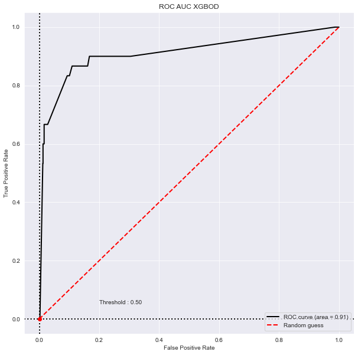

```python
# visualisation courbe ROC xgbod
bc = BinaryClassification(y_valid, y_pred_valid_prob_xgbod, labels=["Class normale", "Class anormale"])

# Figures
plt.figure(figsize=(10, 10))
bc.plot_roc_curve()
plt.title('ROC AUC XGBOD')
plt.show()
```

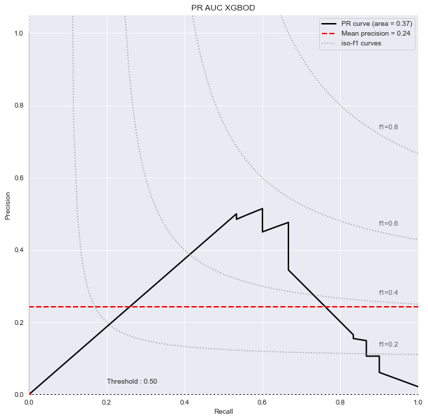

```python
# visualisation de la courbe precision recall xgbod
bc = BinaryClassification(y_valid, y_pred_valid_prob_xgbod, labels=["Class normale", "Class anormale"])

plt.figure(figsize=(10, 10))
bc.plot_precision_recall_curve()
plt.title('PR AUC XGBOD')
plt.show()
```

## 5.3 Stratégie d'échantillonnage

Le ré-échantillonnage des données dans le cadre du déséquilibre des classes est aussi possible. L'objectif est de ré-équilibrer le jeu de données, soit en diminuant le nombre d'instance de la classe majoritaire (`undersampling`), soit en augmentant artificiellement le nombre d'échantillons de la classe minoratire (`oversampling`). J'ai implémenté ces méthodes dans le but d'améliorer la précision du XGBoost, les performances étaient moins bonnes. De même pour la méthode `SMOTE`qui semblait pourtant pertinente, avec la création d'un nombre d’observations synthétiques sur les segments entre éléments proches de la classe minoritaire.

# 6. Résultats

[output not shown]

# 7. Pour aller plus loin

Lors de la phase d'EDA, j'ai pu constaté une forte similarité entre les doublons issus de $xtrain$ et de $xtest$. Il aurait aussi été pertinent d'analyser si des doublons communs existent entre les deux jeux de données : si tel est le cas, on pourrait attribuer au doublon de $xtest$ la valeur de la classe du doublon $xtrain$.

# 8. Sources

- [Analyse Exploratoire des donnés](https://towardsdatascience.com/exploratory-data-analysis-eda-python-87178e35b14)
- [Choix des métriques](https://www.quantmetry.com/blog/classification-et-desequilibre-de-classes/)
- [Gradient Boosting](https://scikit-learn.org/stable/modules/generated/sklearn.ensemble.GradientBoostingClassifier.html)
- [XGBoost (doc)](https://xgboost.readthedocs.io/en/latest/)
- [XGBOD (papier)](https://arxiv.org/abs/1912.00290)
- [XGBOD (doc)](https://pyod.readthedocs.io/en/latest/_modules/pyod/models/xgbod.html)
- [Méthodes d'échantillonnage](https://machinelearningmastery.com/smote-oversampling-for-imbalanced-classification/)